# Reaction presence/absence analysis for IBD patients

Jan Taubenheim

2022-04-07

# 1 Introduction

I created context specific models of different IBD patients (longitudinal data) from biopsy samples. Afterwards I used the presence/absence information of the different reactions to gain information what of these are associated with the disease activity score of the patients. I did this analysis using LMM to explain HB/Mayo scores by the presence/absence of the reaction.

# 2 Results

The general idea was to cluster the reaction for presences and absence for correlation to each other, in order to reduce the dimensionality a little. So it might be a good idea to get see how many clusters there are and how large each of them is.

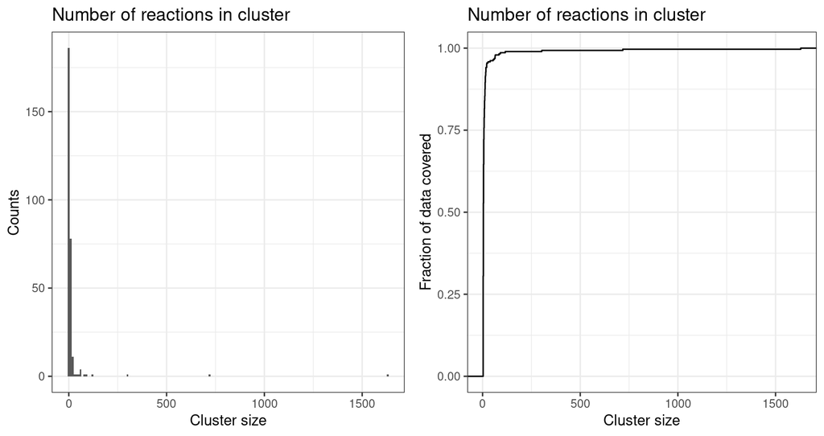

```r
subsystems <- fread("./Statistics/dat/subsystems.csv")
cluster <- fread("Statistics/results/PA_DBSCAN_Cluster.csv")
stats <- fread("Statistics/results/PA_LMMsRandomPatient_fullCoefTable.csv")
sigs <- stats[padj<= 0.05,]

cluster.size <- cluster[, .(cluster_size = .N), by=ClusterID]
cluster.size.hist <- ggplot(cluster.size, aes(x=cluster_size)) +
    geom_histogram(binwidth = 10) +
    labs(x= "Cluster size", y= "Counts", title = "Number of reactions in cluster")+
    theme_bw()

cluster.size.ecdf <- ggplot(cluster.size, aes(x=cluster_size)) +
    stat_ecdf()+
    labs(x= "Cluster size", y= "Fraction of data covered", title = "Number of reactions in cluster")+
    theme_bw()

cowplot::plot_grid(cluster.size.hist,
                   cluster.size.ecdf,
                   ncol = 2)
```

It is worthwhile to get an impression how much reduction in dimensionality was achieved.

```r
clusterSummary <- data.frame(
                             rxns = nrow(cluster),
                             cluster = max(cluster[,cluster]),
                             rxns_in_cluster = nrow(cluster[cluster != 0,]),
                             reduction = round((max(cluster[,cluster])+nrow(cluster[cluster == 0, ]))/ nrow(cluster),2),
                             significant_rxns_and_cluster = nrow(sigs),
                             significant_rxns = nrow(cluster[rep.rxn %in% sigs[,rn],]),# nrow(sigs[!rn %in% cluster[,ClusterID],]) + nrow(cluster[ClusterID %in% sigs[,rn]]),
                             largest_cluster = max(cluster.size[,cluster_size]),
                             smalles_cluster = min(cluster.size[,cluster_size]),
                             mean_cluster = round(mean(cluster.size[,cluster_size]),2),
                             median_cluster = median(cluster.size[,cluster_size])
                             )

clusterSummary <- t(clusterSummary)
colnames(clusterSummary) <- c("Value")
DT::datatable(clusterSummary)
```

|  | Value |
| --- | --- |
| rxns | 4901 |
| cluster | 287 |
| rxns_in_cluster | 3272 |
| reduction | 0.39 |
| significant_rxns_and_cluster | 283 |
| significant_rxns | 883 |
| largest_cluster | 1629 |
| smalles_cluster | 3 |
| mean_cluster | 17.02 |
| median_cluster | 4 |

So generally there are many small clusters and just a few larger ones. I identified 283 reactions/clusters to be significantly associated to a change in HB/Mayo scores if present. That translates to a total of 883 reactions which are associated to the HB/Mayo changes. I next asked how is the distribution of coefficients in the identified cluster/rxns is.

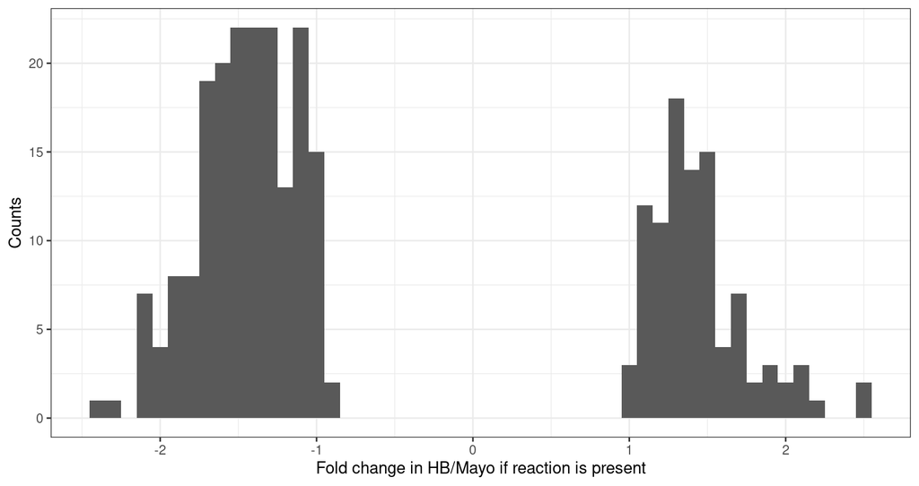

```r
sigs.hist <- ggplot(sigs, aes(x=Estimate)) +
    geom_histogram(binwidth=0.1)+
    labs(x = "Fold change in HB/Mayo if reaction is present", y = "Counts") +
    theme_bw()
sigs.hist
```

# 3 Subsystem presences

## 3.1 Reaction counting in subsystems

Let us look into the subsystems which are encoded within the reactions/cluster which are significantly associated to HB/Mayo.

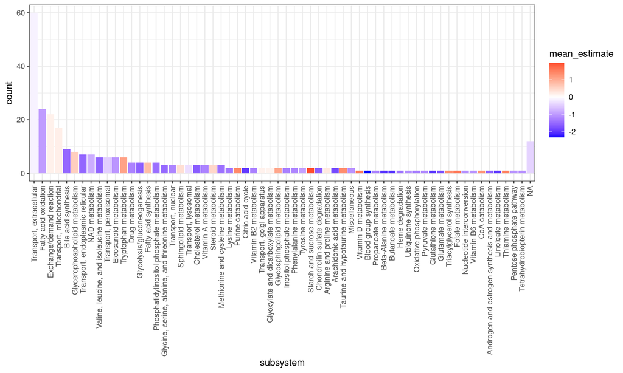

```r
# get all significant reactions
rxns <- cluster[rep.rxn %in% sigs[,rn], Rxn]

# get the annotation for these reactions
setkey(subsystems, "reaction")
subs <- subsystems[rxns]

# merge the stats with the reactions - use the clusterID to merge as well
subs <- merge(subs, cluster, by.x = "reaction", by.y = "Rxn", all.x=T)
subs <- merge(subs, sigs, by.x = "reaction", by.y = "rn")

# create a barplot to get an idea for the subsystems
subsBarDat <- subs[,.(count = .N, mean_estimate = mean(Estimate)), by=subsystem]
subsBarDat <- subsBarDat[,subsystem := factor(subsystem, levels= unique(subsystem)[order(count, decreasing = TRUE)]),]

subs_barplot <- ggplot(subsBarDat, aes(y= count,x = subsystem, fill = mean_estimate)) +
    geom_bar(stat="identity") +
    scale_fill_gradient2(high="red",low="blue")+
    theme_bw()+
    theme(axis.text.x = element_text(angle=90, vjust=0.5, hjust=1))
subs_barplot
```

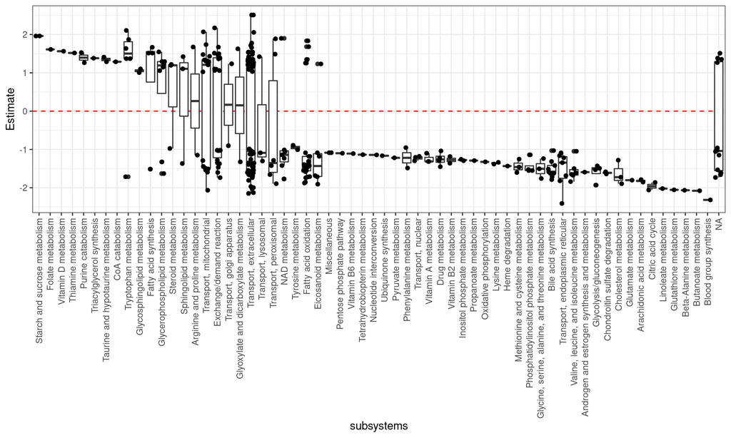

```r
# order the subsystems for mean estimate association
subs_order <- subs[, .(mean_est = mean(Estimate)), by = subsystem]
subs[,subsystems := factor(subsystem, levels=unique(subs_order[order(mean_est,decreasing=TRUE), subsystem]))]

subs_jitterplot <- ggplot(subs, aes(x=subsystems, y= Estimate)) +
    geom_hline(yintercept=0, color = "red", linetype=2)+
    geom_boxplot(outlier.shape = NULL)+
    geom_jitter(height=0, width=0.3)+
    theme_bw()+
    theme(axis.text.x = element_text(angle=90, vjust=0.5, hjust=1),
          legend.position = "none")
subs_jitterplot
```

## 3.2 Subsystem enrichment

OK this plot is somewhat misleading, as it does not reflect anything on how large a subsystem is and how many reactions of these are actually significantly associated. Thus I will perform an hypergeometric enrichment analysis on the significant reactions.

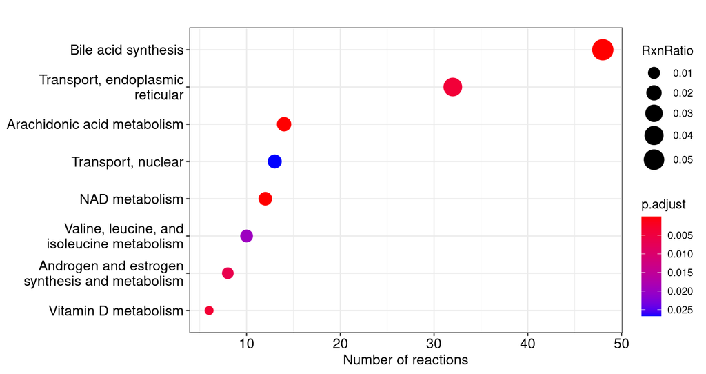

```r
hgt <- enricher(rxns, TERM2GENE = subsystems)
clusterProfiler::dotplot(hgt, x = "Count") +
    labs(x="Number of reactions", size = "RxnRatio")
```

This looks a lot like the results obtained before by the colormore22.

## 3.3 GSEA on Subsystems

To give this association between number of reactions significantly associated and the subsystem involved more statistical foundations, I performed a gene set enrichment analysis. Here is a ridgeplot of the results.

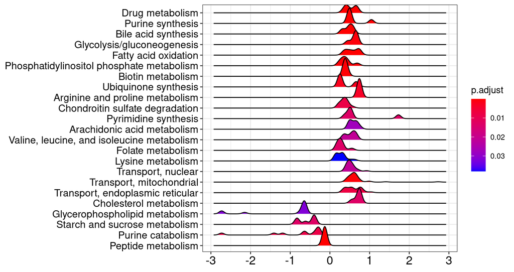

```r
gsea <- readRDS("Statistics/results/PA_GSEASubsystems.RDS")
ridgeplot(gsea, label_format=90) + theme(axis.text.y= element_text(size = 12))
```

So there is definitely some overlap, but far less subsystems are enriched in this analysis compared to just the reactions to subsystem mapping. So lets check how large the overlap between all methods is.

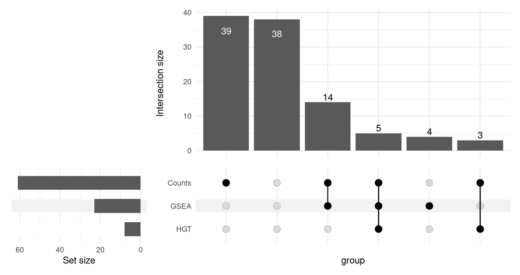

```r
require(ComplexUpset)

# get the subsystems of each analysis
subsystems.names <- unique(subsystems[,subsystem])
tbl.gsea <- data.table(as.data.frame(gsea))
tbl.hgt <- data.table(as.data.frame(hgt))

mat <- matrix(FALSE, nrow = length(subsystems.names), ncol = 3, dimnames = list(x=subsystems.names, y=c("Counts","HGT","GSEA")))

mat[unique(subs[!is.na(subsystem),subsystem]),"Counts"] <- TRUE
mat[tbl.gsea[,ID], "GSEA"] <- TRUE
mat[tbl.hgt[,ID], "HGT"] <- TRUE

upset(as.data.frame(mat), intersect = colnames(mat))
```

Common in all three analysis are: Transport, endoplasmic reticular, Transport, nuclear, Valine, leucine, and isoleucine metabolism, Bile acid synthesis, Arachidonic acid metabolism.

# 4 Distance for discrimination

So we can now check whether these analysis gives the most valuable discrimination for low and high HB/Mayo scores. To this end I will perform a PERMANOVA on the Jaccard distances between the different samples for the different subsets of reactions. At the same time, I will plot a PC-ordination of the distances to visualize the result.

```r
# read the original extraction matrix
mat.rxns <- read.csv("../results/ModelAnalysis/rxnIdMat.GL10-L50-GU90.MatjesAbsorption.colormore3D.csv", row.names = 1)

mat.rxns2 <- mat.rxns
mat.rxns[,] <- 0
mat.rxns[mat.rxns2 == "True"] <- 1
rm(mat.rxns2)

# load meta data
clinic <- fread("../resources/ClinicalData.csv")
meta <- fread("../resources/META_emed_future.csv")
blcklst <- fread("../resources/sampleBlacklist.csv")

# merge meta and clincal data
meta[,PatientID_Time := paste(PatientID, Time_seq, sep ="_")]
meta <- meta[Time_seq != -1,]
meta <- merge(meta,clinic, by="PatientID_Time", all.x=TRUE, suffix = c(".meta",""))

# remove degraded samples
blckSmpls <- blcklst[relevance < 2, Sample]
meta <- meta[!(SeqID %in% blckSmpls),]
mat.rxns <- mat.rxns[,!(colnames(mat.rxns) %in% blckSmpls)]
meta <- meta[SeqID %in% colnames(mat.rxns),]

# sort the rxns counts to correspond to the meta data
mat.rxns <- mat.rxns[,meta[,SeqID]]

# generate a list for each reaction sets
lst.rxns <- list(
                 "Counts" = rxns,
                 "HGT" = subsystems[subsystem %in% data.frame(hgt)[,"ID"],reaction],
                 "GSEA" = subsystems[subsystem %in% data.frame(gsea)[,"ID"],reaction],
                 "All" = rownames(mat.rxns)
                 )

pca.plots <- list()
adonis.stats <- list()
# set the permutations correctly
perm <- how(nperm =999, blocks = meta[,PatientID])
for(set in names(lst.rxns)){
    vec.rxns <- lst.rxns[[set]]
    # get the distances
    dist.jacc <- dist(t(mat.rxns[vec.rxns,]), method = "binary")
    adonis.stats[[set]] <- adonis2(data=meta,
                            dist.jacc~HB_Mayo_impu,
                            permutations = perm)
    pca <- prcomp(dist.jacc, scale = TRUE, center = TRUE)
    pca.var <- (pca[["sdev"]]^2/sum(pca[["sdev"]]^2)) * 100
    pca.x <- data.table(pca[["x"]], keep.rownames = TRUE)
    pca.x <- merge(pca.x, meta, by.x = "rn", by.y = "SeqID")
    pca.plots[[set]] <- ggplot(pca.x, aes(x = PC1, y = PC2, color = HB_Mayo_impu, shape = Diagnosis)) +
        geom_point(size = 2) +
        theme_bw() +
        labs(x = paste0("PC1 (",round(pca.var[1],2),"%)"),
             y = paste0("PC2 (",round(pca.var[2],2),"%)"),
             color = "HB/Mayo",
             title = set
             ) +
        scale_color_gradient(low = "blue", high = "red")
}

adonis.sum <- do.call(rbind,lapply(adonis.stats,function(x) x[1,]))
DT::datatable(adonis.sum)
```

|  | Df | SumOfSqs | R2 | F | Pr(>F) |
| --- | --- | --- | --- | --- | --- |
| Counts | 1 | 7.16639006871511 | 0.1388067233922 | 41.2619584402377 | 0.001 |
| HGT | 1 | 2.10751922774555 | 0.0788731105647641 | 21.9204504136878 | 0.001 |
| GSEA | 1 | 1.35489552548187 | 0.0691697995652862 | 19.0233070225306 | 0.007 |
| All | 1 | 1.53568663597196 | 0.0616722246703074 | 16.8257723267878 | 0.001 |

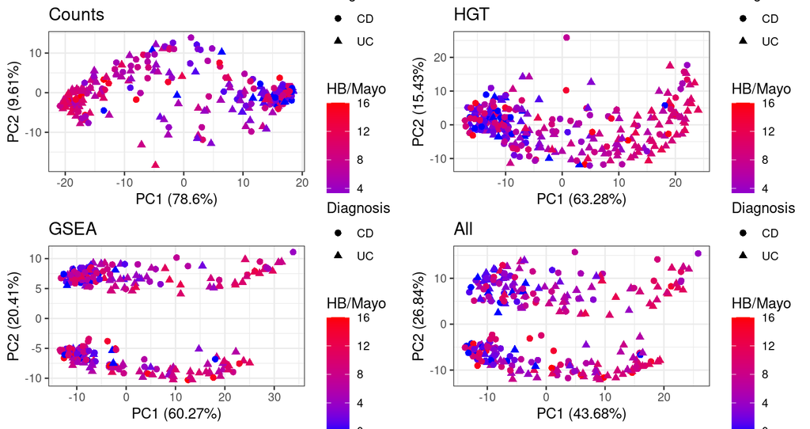

```r
cowplot::plot_grid(plotlist=pca.plots)
```

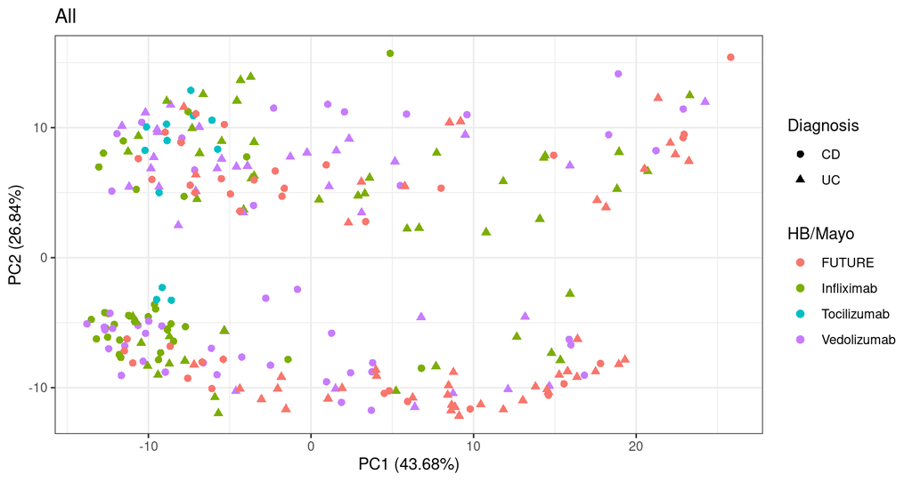

```r
ggplot(pca.x, aes(x = PC1, y = PC2, color =Treatment, shape = Diagnosis)) +
        geom_point(size = 2) +
        theme_bw() +
        labs(x = paste0("PC1 (",round(pca.var[1],2),"%)"),
             y = paste0("PC2 (",round(pca.var[2],2),"%)"),
             color = "HB/Mayo",
             title = set
             )
```